# Starcraft 2 Match Results Based on Various Features of Prior and Within the Game

Kevin Ma

## Introduction

With the new Rstudio tools at our disposal, we are going to look at how a variety of features during the game, including matchup (of the three different species you can choose to play as), upgrade advantage, and more.

# Data source

All data was surveyed and logged by the author (Kevin Ma). There were a few games where players would start the game, and immediately quit out (usually because they didn’t like the species I was playing as, or they realized they committed to doing something else prior). I did not include these points, although it means that “mirror matches” (e.g. Zerg vs Zerg) were much less common to have data on, as online players seem to dislike playing mirror matches.

## Data Collection Period and Limitations

Before we analyse the data, I would like to address certain limitations of the data, and potential factors of data collection which may skew results.

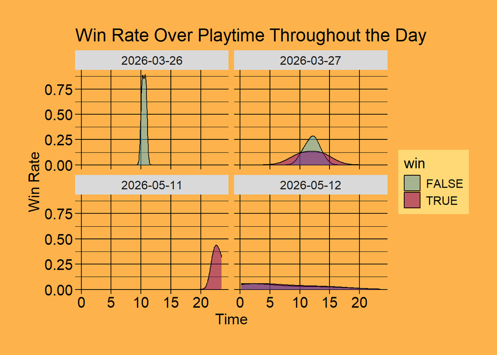

# Time density

I’m sure it’s pretty obvious now that I crammed for this assignment (not used to being exposed on this aspect, so I’ll awkwardly apologize to you and myself and will resolve to manage my time better for future projects). Luckily for me, consecutive games played over a short period of time didn’t seem to affect my win/loss ratio so much as the *specific time* I was playing at, with the trends looking either near identical, or simply only had wins or losses. One graph even has a bell curve shape, implying that the time of day I played did not influence win rate. Looks like we should have (relatively) unbiased data on this front.

# Small data size

Unfortunately, even with an additional 21 samples for a total of 42 samples, I simply wasn’t able to collect enough to fit into the many categories with enough data left over to make any kind of confident inference. Still, we can speculate with what we have.

# Rank and the Online Space

While I played random to get a relatively even split of the 3 species you can play as, the online scene was much more skewed towards certain species over the other: in the diagram below, we can see the majority of players I matched against preferred Zerg, then Terran, and a much smaller amount played Protoss. Combining this with the above problem means that data for certain matchups had as few as one data point, and so don’t actually have relevant data unfortunately.

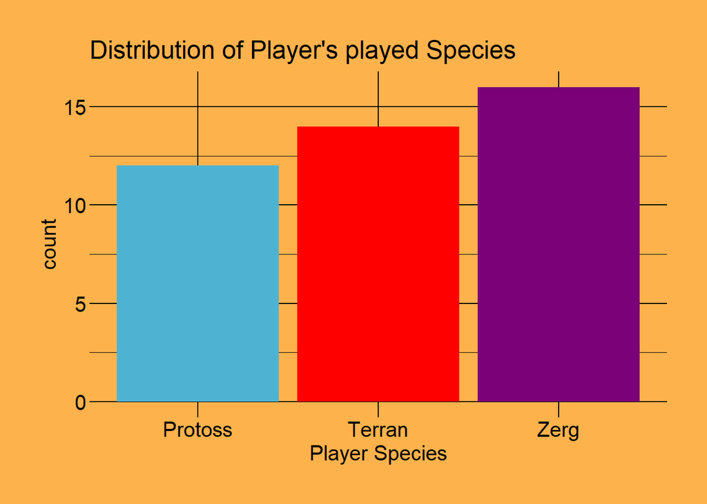

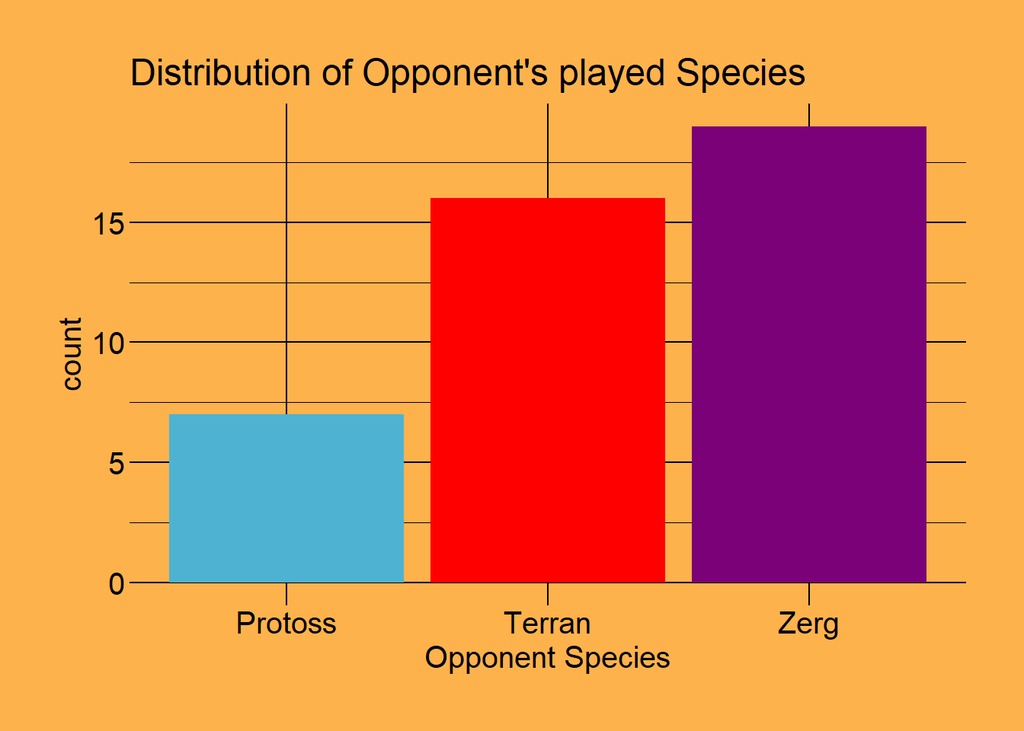

## Matchups in Starcraft 2

# Flat win rate

Starcraft 2 species have different pro’s and con’s to them, and even at a top level none of the three have stood out as succeeding significantly more than the others. However, at lower levels some of them can be more executionally demanding, meaning certain species can have a higher chance of succeeding compared to others. Furthermore, species can also have favourable interactions into other species specifically, due to unit compositions or other forms of pressure. Let’s see the win rate for each species fighting each other (disregarding the mirror matchups, e.g. Zerg vs Zerg, as that will obviously be a 100% win rate for Zerg, or 0% depending on how you look at it really.)

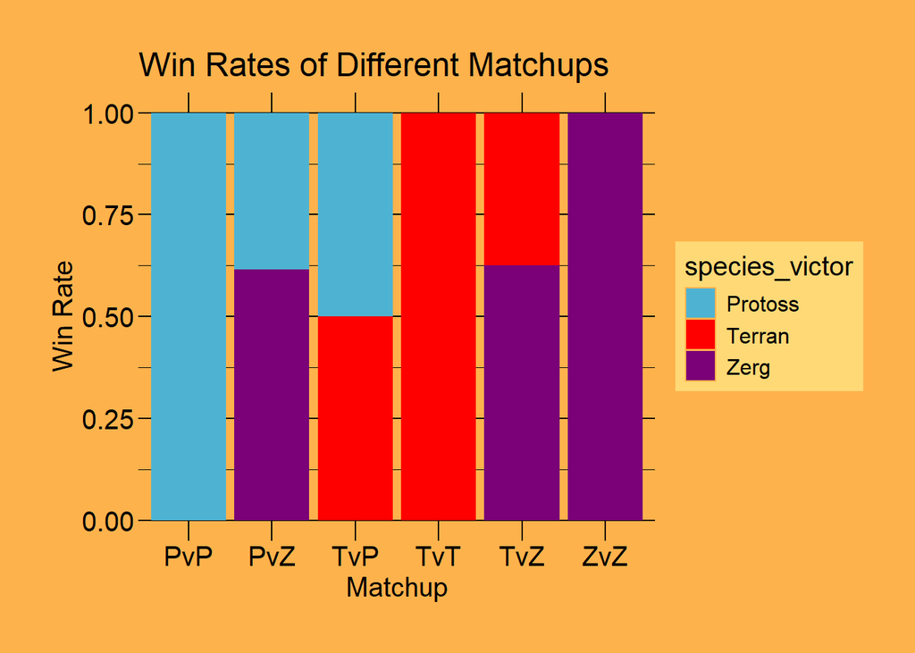

# Change Over a Game’s Duration

Introducing the factor of time can show us the strength of each species as the duration of a game increases. Certain species might prefer to win quicker, while others may like to take their time more.

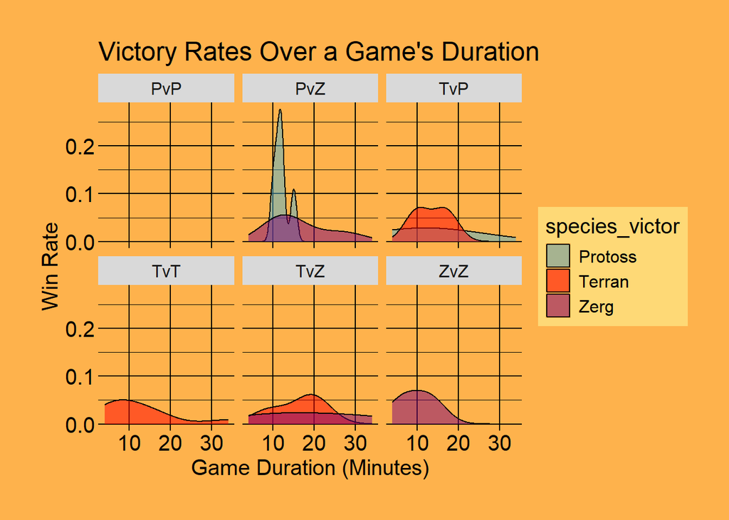

From these plots, we can see some interesting win patterns. In the Protoss vs Zerg matchup, it seems protoss’ highest chance of winning lies in the 10-15 minute range, and outside of (or even before that) we can see zerg winning. This could be potentially informative on how to play the match as Zerg: statistically, trying to survive and not win until after 15 minutes drastically increases your chances of winning. The same seems true for Terran vs Protoss, with Protoss being significantly at risk of losing in the early game, even though overall we know the matchup has a 50/50 win rate. Terran vs Zerg seems the hardest to pin down, as zerg seems likely to win at almost any given moment, but terran’s chances of winning seem most potent around the 15-20 minute mark. Again, since the mirror matchup only shows us winning data of one species, it is not useful and can be ignored (one of which is entirely blank, as it only had one data point).

Of course, these results should be taken with a reasonable amount of skepticism: perhaps the only reason why Protoss vs Zerg has such a skewed win rate in the early game is due to the lack of Protoss players on the opponent’s side, or a lack of data in general. To make sure our data isn’t being skewed by game duration, let’s take a look at player win rate over a game’s duration.

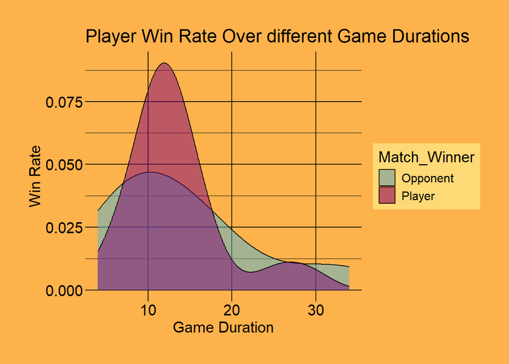

While there is admittedly a large skew, as it seems the player tended to fare better earlier on, the trend of both the opponent and player winning seems roughly similar enough to say that our previous findings were not influenced by player/opponent species choice frequency.

## Upgrade Advantage

With more data, we can more accurately see how/if having an upgrade advantage affects the probability of success.

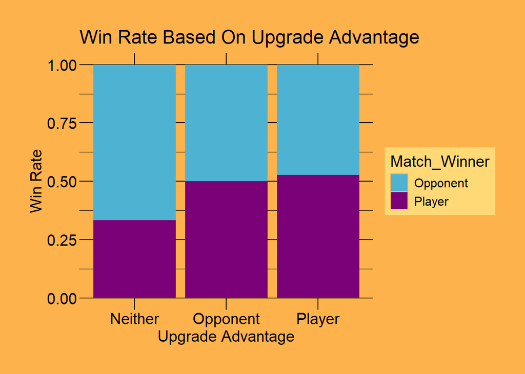

While this graph on first glance may not seem to have anything interesting about it, with upgrade advantage and disadvantage having a roughly even win rate, when on an even upgrade amount the opponent seems to be much more effective than the player. extrapolating from other information, this might have to do with the opponent having a higher win rate at an incredibly early game duration, as acquiring upgrades takes time, meaning that doing well before upgrades are available to either side would give the opponent a better success rate when neither side has upgrades.

## Snowball Effect

Lastly, we will look at the “snowball effect”, in tandem with matchups. The snowball effect in games is the idea of small leads compounding in to a larger and larger gap in advantage, which inevitably results in a victory.

# Number of Engagements

In project 2, I looked at this using the difference of the duration of the whole game minus first fight’s time, with the idea being that the result of that fight would shortly thereafter determine a winner. However, this did not account for drawn out matches, where small initial leads take time to allow for a win. To (partially) circumvent this, I have included a new variable, the number of fights. With this, we can see if there was a small number of fights over a long game which resulted in a victory (this would seem to imply a snowball effect).

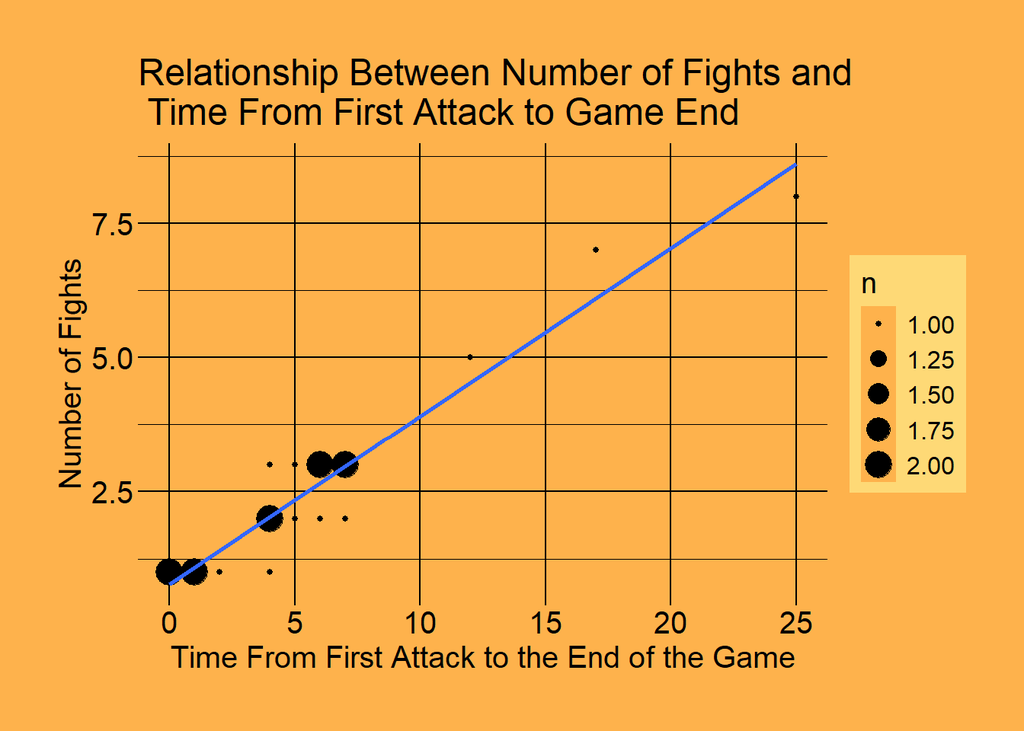

We can see a very clear linear relationship forming here. This is a good sign that our prior data is actually indicating snowball effect. We favor this data over the number of engagements, since number of engagements was more recently implemented, and thus only has 21 data points, and since it seems to tell a similar story, we will go back to simply using the difference of the game duration to the time of the first attack for seeing the value of this “snowball effect”.

# Snowball effect across matchups

Let’s see how much the snowball effect is prevalent in different matchups.

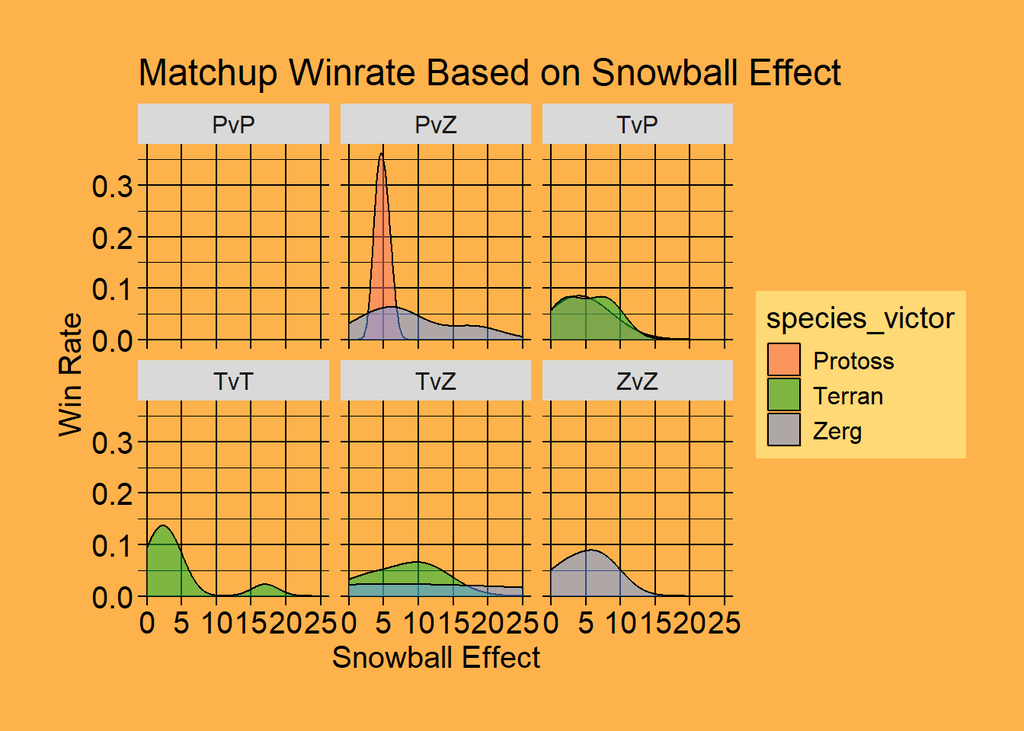

Annoyingly, our data looks incredibly similar to the Victory Rates Over a Game’s Duration graph. This would be explained if the first engagement’s timing’s were pointed towards a specific point (as it would simply be the prior graph minus a constant) - let’s check to see if this is the case.

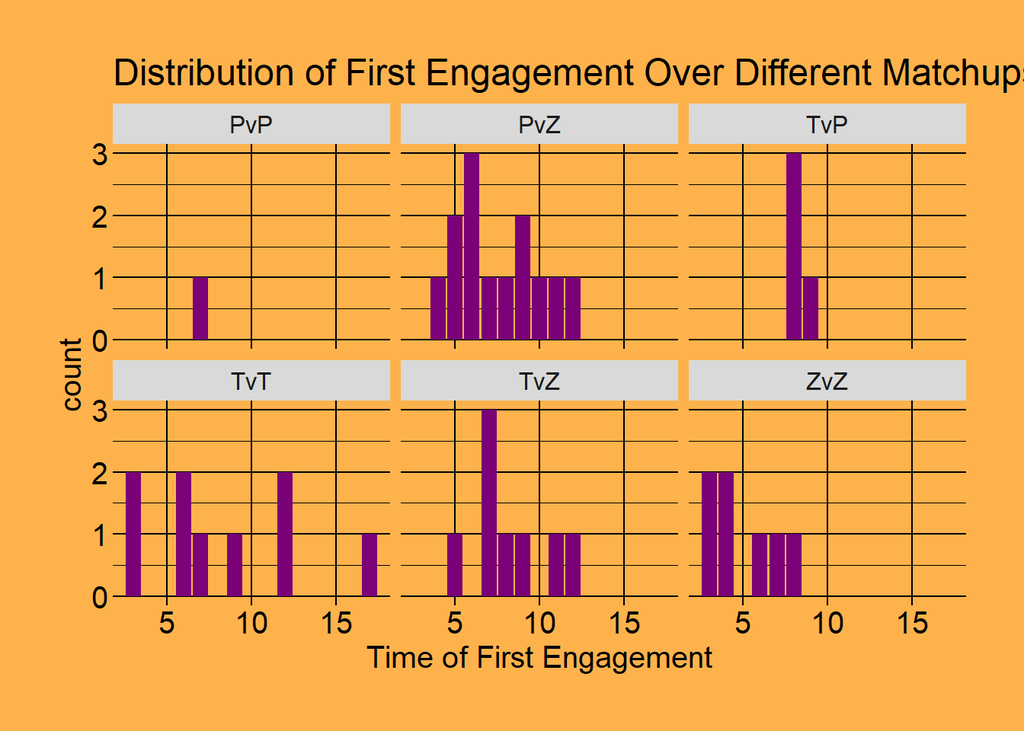

However, in this data we can’t see any such constant arising in the matchups, so it’s likely what we’re seeing here is simply a result of the game: for instance, the most obvious similarity with the spike in Protoss vs Zerg is likely caused by the victory happening early on, meaning there is less variance the first fight could have had (as it has to be less than the game’s duration).

What’s interesting is that the protoss victory in the graph is almost exactly at the 5 minute mark, implying that it almost always takes that much time from the first engagement for the protoss to win. This skew is likely due to Protoss playstyle, as they are very easily able to destroy an opponent’s army quickly, meaning the opponent has less opportunities to rebuild before they lose.

Combining the two graphs, we can actually see that the Terran vs Terran matchup is extremely unforgiving, with fights often being started near the beginning of the game, and the result of the match following quickly after. We can also see a strange bump much later on: again, this is actually quite telling to the specific matchup in game, as Terran versus Terran can often be an excruciating, long paced game, which might make impatient players favor trying to settle the game early. The Zerg vs Zerg matchup also seems to follow this style of early aggression, although rarely ever going to longer, more drawn out games. Zerg tends to be the most aggressive species, so again this data supports how the species tend to play (incidentally, Protoss vs Protoss is known for being the most chaotic, difficult to navigate matchup, which may be the reason why it is avoided).

# Problems With This Method

In retrospect, this data, while likely more accurate than what I had before, still could likely be much better as it runs into the same problem of not accounting for small leads in fights which lead to bigger and bigger wins in fights which ultimately result in a win. It is also worth point out that the game duration would naturally be influenced by the number of fights (as fights in game take place over time).